# KuGou Daily Top100 Exploratory Data Analysis

Course Project

2026-11-17

# 1. Data and Scope

Data quality is checked before any exploratory figure is produced. This report analyses KuGou Daily Top100 as a standalone dataset. Spotify and Douyin fields are not used. The analysis defines the observation unit clearly, separates actual observations from calendar coverage, retains missing values as missing rather than converting them to zero, and avoids duplicate weighting.

# 2. Data Structure and Quality

```
## **Coverage summary:** 73,000 daily records, 2,635 unique tracks, across 2024-11-14–2026-11-13 (730 days).
```

| Check | Result |
| --- | --- |
| Exactly 100 records per day | 1 |
| Duplicate date-rank pairs | 0 |
| Missing track IDs | 0 |
| Missing artist names | 1 |
| Missing album names | 6 |
| Missing lyric status | 0 |

Each row is interpreted as one track-date chart observation. An absent track is not recoded as zero popularity, and `time_on_chart` is treated as observed chart persistence within this archive rather than an official lifetime measure. Because the KuGou Daily Top100 is complete for every date, an additional observation-density figure would be redundant; turnover and persistence are more informative.

The report follows the chart lifecycle: first, it describes daily chart turnover; second, it examines how long songs remain visible and identifies the longest-running songs; third, it evaluates artist-level chart presence and ranking performance; finally, it examines genre, mood, and duration patterns. Cross-platform overlap, temporal Jaccard, and first-observed timing are reserved for the later integrated analysis because they require Douyin data.

# 3. Exploratory Analysis

## 3.1 Daily Chart Turnover

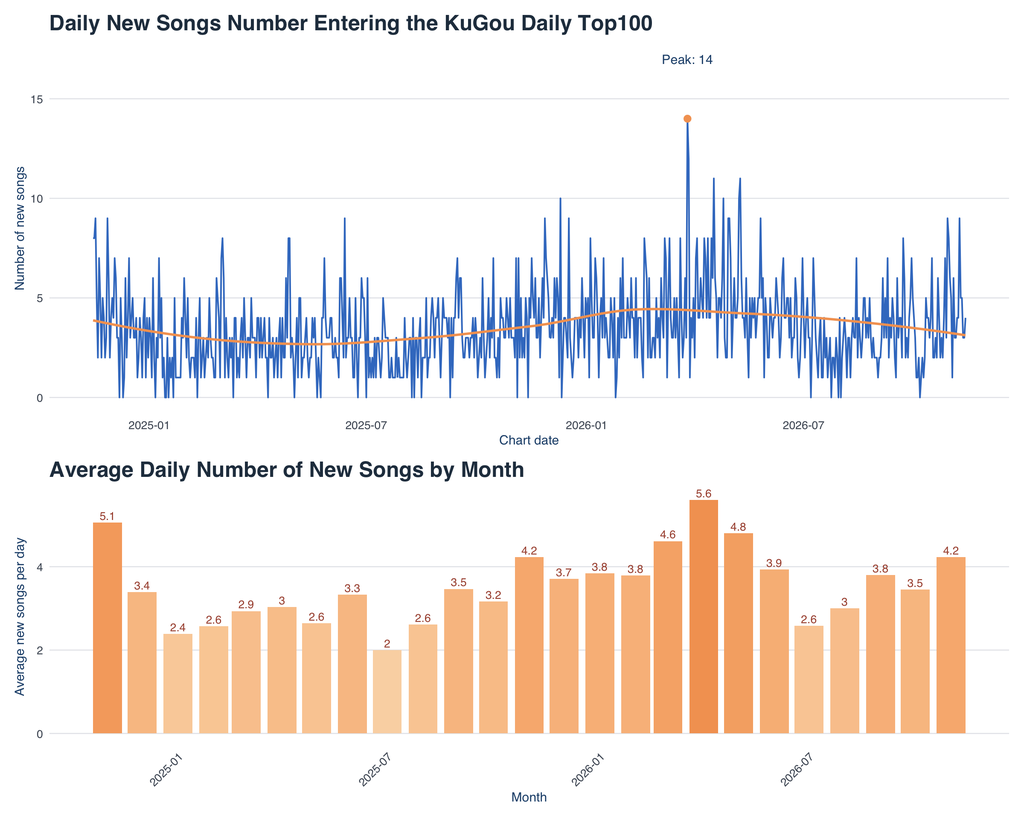

The KuGou chart changes continuously, but most days introduce only a small number of new songs. The monthly averages show that turnover varies across the observation period, indicating that chart entry activity is not constant over time.

### Interactive View: Daily Chart Turnover

The interactive view complements the static turnover figure by allowing exact dates and daily new-entry counts to be inspected with hover, zoom, and pan controls.

[interactive chart not shown]

## 3.2 Chart-Stay Duration and Longest-Running Songs

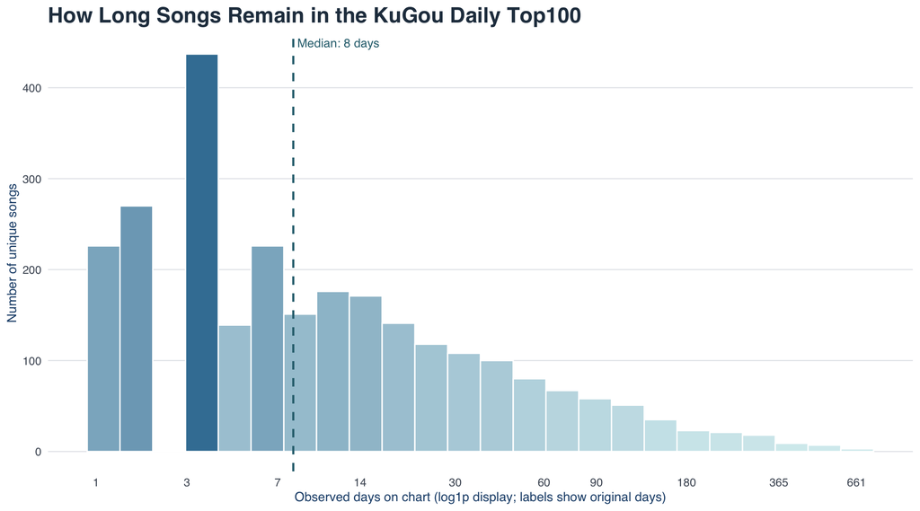

The persistence distribution establishes the overall lifecycle of songs on the chart. The log1p display makes the dense short-stay region visible while retaining the original-day labels; all calculations remain on the original day scale.

Songs with the longest observed Daily Top100 persistence

| Song title | Artist | Genre | Mood | Best rank | Days on chart |
| --- | --- | --- | --- | --- | --- |
| 爱错 | 王力宏 | Pop | Sad / Lonely | 5 | 661 |
| 唯一 | G.E.M.邓紫棋 | Pop | Romantic / Affectionate | 1 | 601 |
| 我怀念的 | 孙燕姿 | Pop | Playful / Fun | 13 | 597 |
| 晴天 | 周杰伦 | Pop | Romantic / Affectionate | 21 | 585 |
| 雨爱 | 杨丞琳 | Pop | Romantic / Affectionate | 9 | 565 |
| 第57次取消发送 | 菲菲公主（陆绮菲） | Pop | Playful / Fun | 1 | 490 |
| 舍得 | 王唯旖 | Pop | Energetic / Positive | 5 | 477 |
| 偏爱 | 张芸京 | Pop | Playful / Fun | 12 | 473 |
| 恋人 | 李荣浩 | Dance / Electronic | Nostalgic / Reflective | 2 | 471 |
| 离开我的依赖 | 王艳薇 | Pop | Romantic / Affectionate | 1 | 461 |
| 落了白 | 蒋雪儿Snow.J | Pop | Romantic / Affectionate | 5 | 456 |
| 青花瓷 | 周杰伦 | Pop | Playful / Fun | 43 | 441 |
| 特别的人 | 方大同 | R&B / Soul | Sad / Lonely | 1 | 433 |
| 茶花开了 | 王睿卓 | Dance / Electronic | Playful / Fun | 9 | 416 |
| 爱情讯息 | 郭静 | Pop | Sad / Lonely | 2 | 414 |

The table provides concrete examples of long-running songs and supports the later interpretation of which artists and music characteristics are associated with sustained chart visibility.

## 3.3 Artist Chart Presence and Ranking Performance

[figure not shown]

This figure links artist exposure and ranking performance in one view. The horizontal position and point size show how many distinct songs an artist contributed, while colour and the rank-range line show whether those songs tended to achieve stronger or weaker best ranks. This is descriptive evidence, not a causal measure of platform preference.

## 3.4 Music Characteristics

### Genre Composition

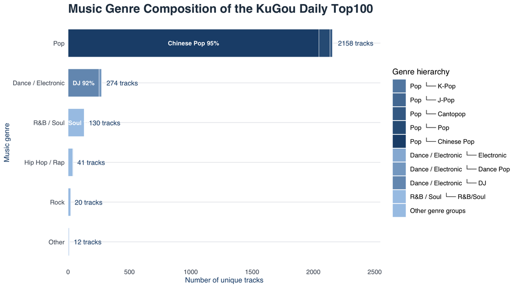

The chart is concentrated in a small number of genre categories. This shows that the KuGou Daily Top100 has a clear genre composition rather than an even distribution across all classified music types.

### Best Chart Rank by Genre

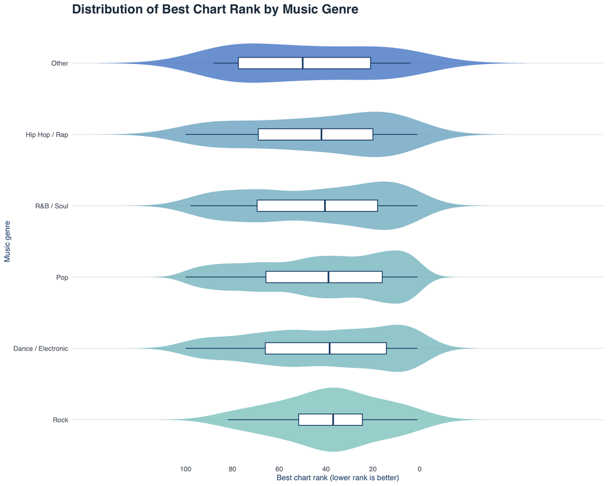

### Mood Composition

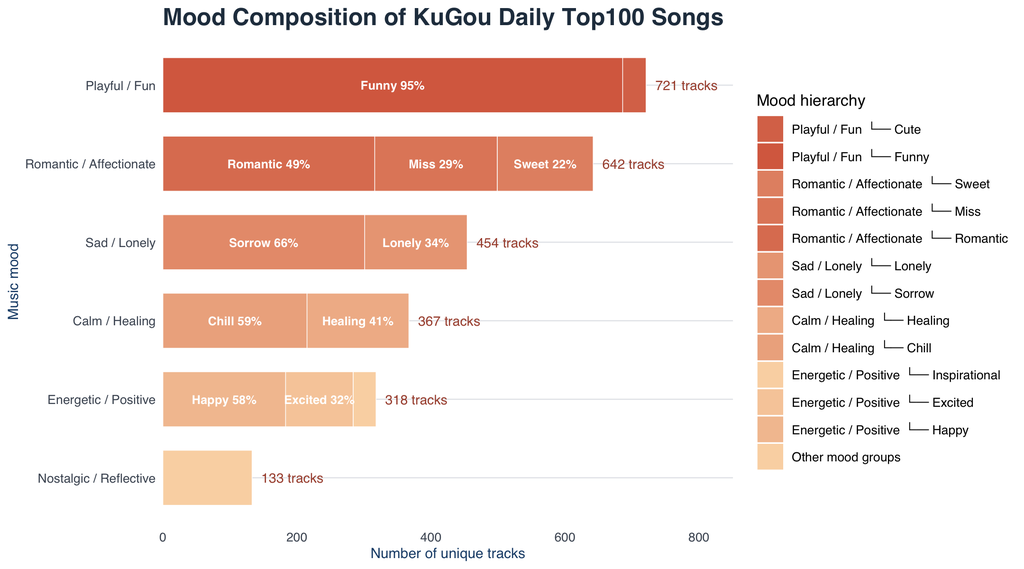

### Best Chart Rank by Mood

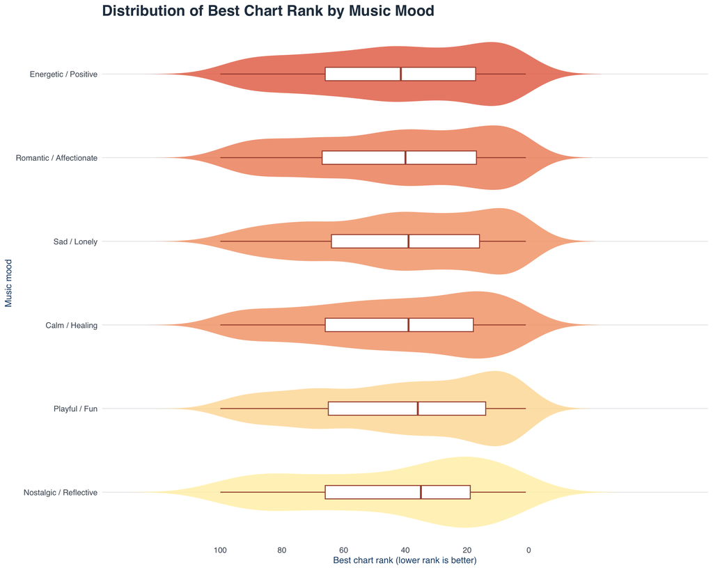

Genre and mood use harmonized categories for cross-platform comparison: six broad genre groups and six grouped mood categories. The original detailed categories remain in `genre_category` and `mood_category`. KuGou categories are rule-assisted screening results rather than native KuGou labels; interpretations should consider `taxonomy_review_required`.

### Song Duration Distribution

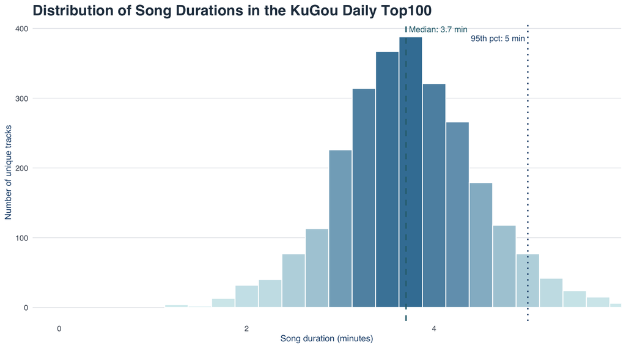

# 4. Findings and Limitations

- The data cover 2024-11-14 to 2026-11-13: 730 days, 73000 daily chart records, and 2635 unique tracks.
- The median peak rank is 39; median observed chart persistence is 8 days; the maximum is 661 days.
- Because a complete Daily Top100 is available each day, the daily mean rank has limited variation; new entries, Top10 frequency, peak rank, and persistence are more informative.
- Genre and mood assignments are rule-assisted screening variables with classification risk; this report describes distributions and associations, not causal effects.